# PLSC30500, Fall 2024

Part 2. Summarizing distributions (part b)

Andy Eggers

# Summarizing joint distributions

## Motivation

Suppose we have two RVs $X$ and $Y$

- number of heads in one coin flip and number of green balls drawn from urn in 6 tries
- age and height of randomly selected student
- whether randomly selected citizen served in military and supports a foreign war

We know the joint PMF/PDF $f(x, y)$ and joint CDF $F(x, y)$.

How can we summarize the relationship between $X$ and $Y$?

## Covariance

$$\text{Cov}[X, Y] = {\textrm E}\left[ (X - {\textrm E}[X])(Y - {\textrm E}[Y]) \right]$$

Intuitively, “Does $X$ tend to be above ${\textrm E}[X]$ when $Y$ is above ${\textrm E}[Y]$? (And by how much?)”

$$f(x,y) = \begin{cases}
1/3 & x = 0, y = 0 \\\
1/6 & x = 1, y = 0 \\\
1/2 & x = 1, y = 1 \\\
0 & \text{otherwise}
\end{cases}$$

What is ${\textrm E}[X]$? What is ${\textrm E}[Y]$?

Then compute expectation of $(X - {\textrm E}[X])(Y - {\textrm E}[Y])$ (function of two RVs) as above.

## Variance and covariance

Compare:

$$\begin{align}\text{Cov}[X, Y] &= {\textrm E}\left[ \color{blue}{(X - {\textrm E}[X])}\color{orange}{(Y - {\textrm E}[Y])} \right] \\
{\textrm V}[X] &= {\textrm E}\left[ \color{blue}{(X - {\textrm E}[X])}\color{blue}{(X - {\textrm E}[X])} \right]\end{align}$$

- Variance of $X$ is covariance between $X$ and itself.
- Variance can’t be negative but covariance can
- A justification for $^2$ in variance formula

## Geometric representation (1)

Plot the points in $\text{Supp}[X, Y]$ on two axes with point size proportional to $f(x, y)$.

Divide the $x, y$ plane into quadrants defined by $x = {\textrm E}[X]$ and $y = {\textrm E}[Y]$.

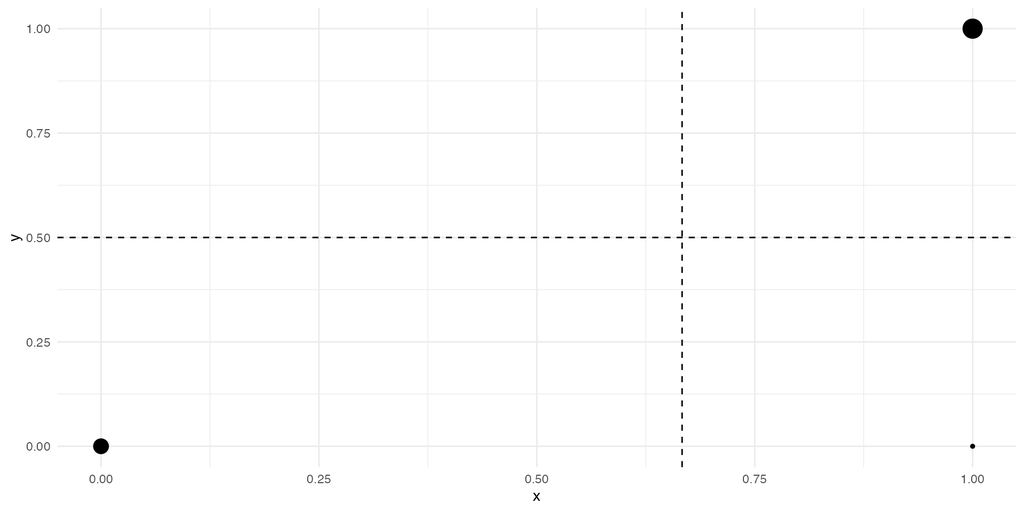

## Geometric representation (2)

For each point $(x, y) \in \text{Supp}[X, Y]$, create a rectangle with $(x,y)$ at one corner and $({\textrm E}[X], {\textrm E}[Y])$ at the opposite corner.

Shade the rectangle green in quadrants I and III (where $(x - {\textrm E}[X])(y - {\textrm E}[X]) > 0$), otherwise red, with intensity proportional to $f(x,y)$.

Covariance (roughly) measures how much green vs red there is.

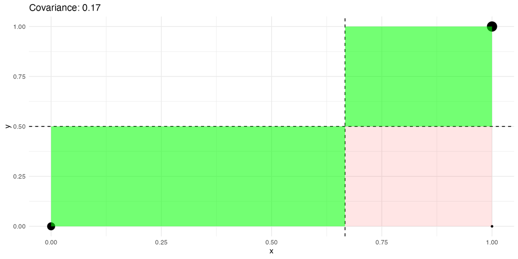

## Geometric representation (3)

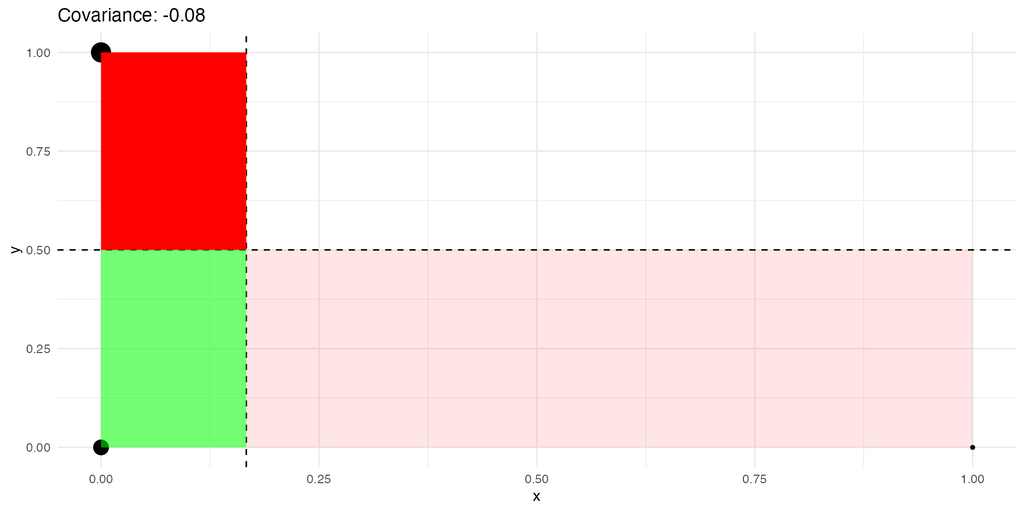

## Geometric representation (4)

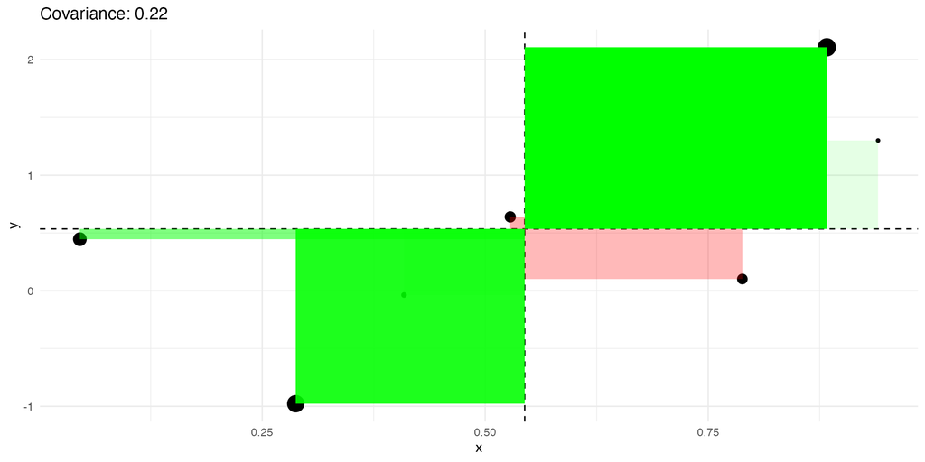

## Geometric representation (5)

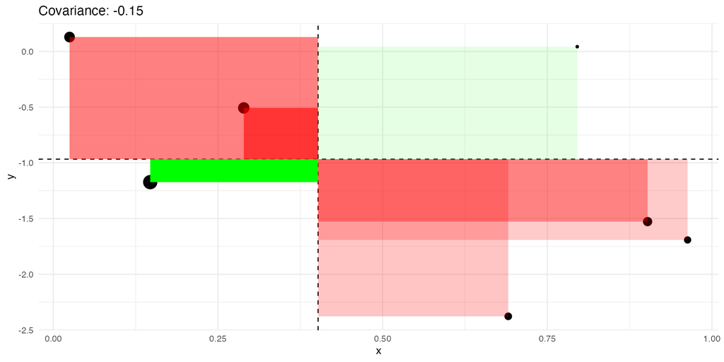

## Alternative formulation

First formulation:

$$\text{Cov}[X, Y] = {\textrm E}\left[ (X - {\textrm E}[X])(Y - {\textrm E}[Y]) \right]$$

As with variance, an alternative formulation:

$$\text{Cov}[X, Y] = {\textrm E}\left[XY\right] - {\textrm E}[X]{\textrm E}[Y]$$

Note:

- if ${\textrm E}[X] = {\textrm E}[Y] = 0$ (e.g. if recentered), both are ${\textrm E}[XY]$
- geometrically, can think in terms of areas of rectangles

## Geometry of ${\textrm E}[XY] - {\textrm E}[X]{\textrm E}[Y]$

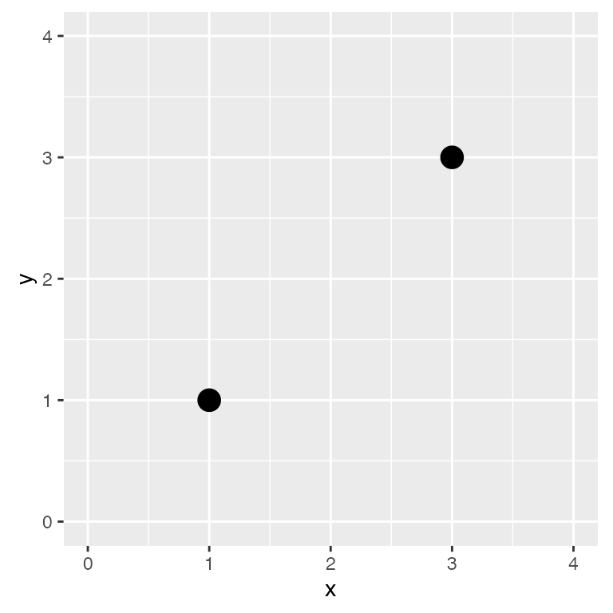

i.e. (1,1) and (3,3) equally likely

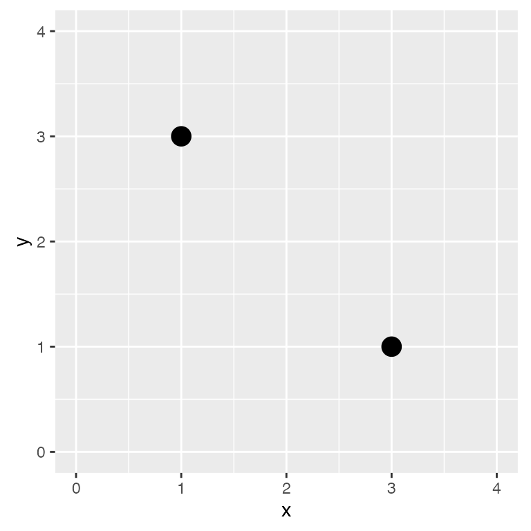

i.e. (1,3) and (3,1) equally likely

## Geometry of ${\textrm E}[X]{\textrm E}[Y]$

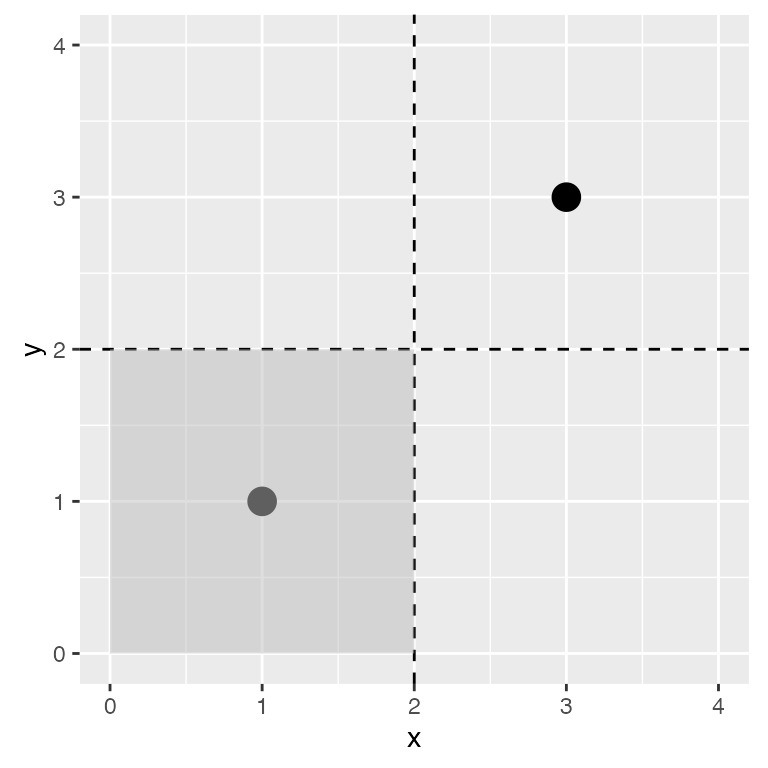

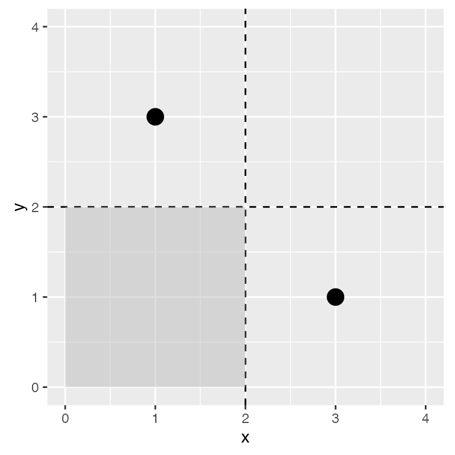

${\textrm E}[X]{\textrm E}[Y]$ is the area below and to the left of the dashed lines

## Geometry of ${\textrm E}[XY]$

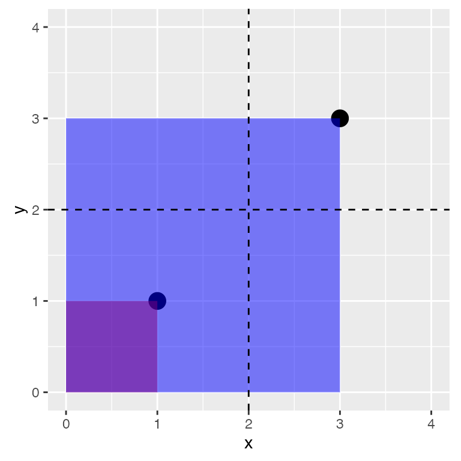

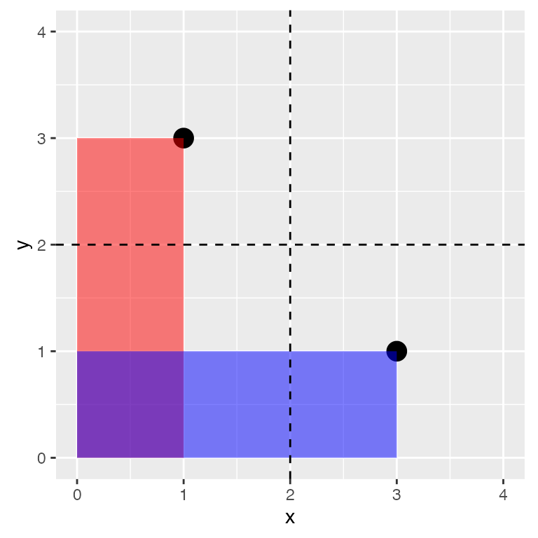

${\textrm E}[XY]$ is the average of the two areas (given equal probability)

## Linearity of expectations, but not variances

If $g$ is a *linear function* or *linear operator* or *linear map*, then $g(x + y) = g(x) + g(y)$. (**Additivity** property.) Examples?

Recall linearity of expectations: ${\textrm E}[X + Y] = {\textrm E}[X] + {\textrm E}[Y]$.

But $\text{Var}[X + Y] \neq \text{Var}[X] + \text{Var}[Y]$

Why not?

## Variance rule (non-linearity of variance)

### A different proof from A&R 2.2.3

$$\begin{aligned}
\text{Var}(X+Y) &= {\textrm E}[(X + Y - {\textrm E}[X + Y])^2] \\\
&= {\textrm E}[(X - {\textrm E}[X] + Y - {\textrm E}[Y])^2] \\\
&= {\textrm E}[(w + z)^2] \\\
&= {\textrm E}[w^2 + z^2 + 2 w z] \\\
&= {\textrm E}[w^2] + {\textrm E}[z^2] + {\textrm E}[2 w z] \\\
&= {\textrm E}[(X - {\textrm E}[X])^2] + {\textrm E}[(Y - {\textrm E}[Y])^2] + 2{\textrm E}[(X - {\textrm E}[X])(Y - {\textrm E}[Y])] \\\
&= \text{Var}(X) + \text{Var}(Y) + 2\text{Cov}(X, Y)
\end{aligned}$$

## Correlation

The **correlation** of two RVs $X$ and $Y$ with $\sigma[X] > 0$ and $\sigma[Y] > 0$ is

$$\rho[X, Y] = \frac{\text{Cov}[X, Y]}{\sigma[X] \sigma[Y]}$$

Correlation is **scale-invariant**: $\rho[X, Y] = \rho[aX, bY]$ for $a, b > 0$

Prove it!

## Proof of scale-invariance of correlation

$$\begin{align}
\text{Cov}[aX, bY] &= {\textrm E}[aX bY] - {\textrm E}[aX]{\textrm E}[bY] \\
&= ab {\textrm E}[XY] - ab {\textrm E}[X]{\textrm E}[Y] \\
&= ab ({\textrm E}[XY] - {\textrm E}[X]{\textrm E}[Y]) \\
&= ab \text{Cov}[X, Y]
\end{align}$$

$$\sigma[aX] = \sqrt{\text{V}[aX]} = \sqrt{a^2 \text{V}[X]} = a \sigma[X]$$

By same argument, $\sigma[bY] = b\sigma[Y]$.

So

$$\begin{align}
\rho[aX, bY] &= \frac{\text{Cov}[aX, bY]}{\sigma[aX] \sigma[bY]} \\
&= \frac{ab \text{Cov}[X, Y]}{a \sigma[X] b \sigma[Y]} = \frac{\text{Cov}[X, Y]}{\sigma[X] \sigma[Y]} \\
&= \rho[X, y]
\end{align}$$

## Conditional expectations

We spent time on **expectations**:

$${\textrm E}[Y] = \sum_y y f(y).$$

Also on **conditional distributions**:

$$f_{Y|X}(y|x) = \frac{f(x, y)}{f_X(x)}$$

Combining the two ideas, we get **conditional expectations**:

$${\textrm E}[Y \mid X = x] = \sum_y y f_{Y|X}(y \mid x).$$

i.e. the expectation of $Y$ at some $x$.

## Illustration

[interactive chart not shown]

## Another illustration

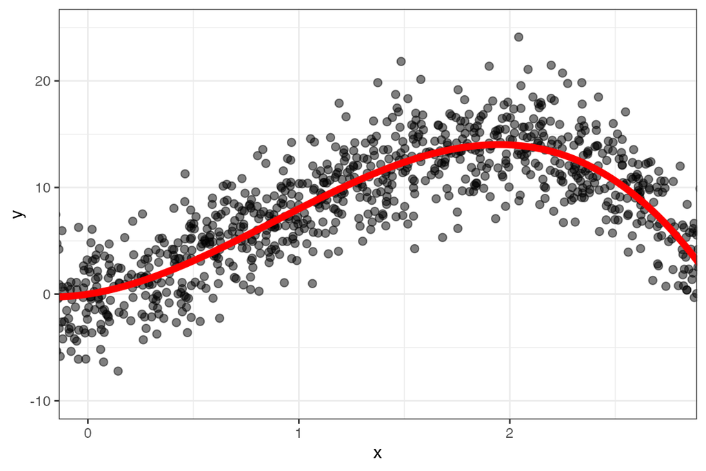

## Illustration (2)

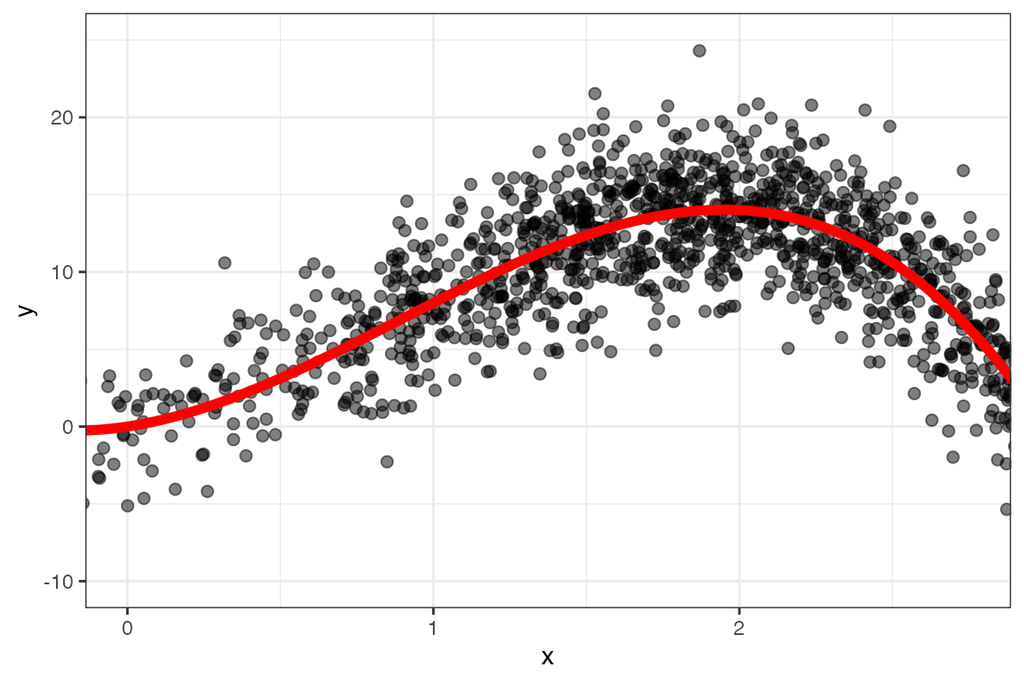

(Red line is ${\textrm E}[Y | X = x]$, dots are a sample from $f(x, y)$)

## Conditional variance

Two formulations:

$${\textrm V}[Y | X = x] = {\textrm E}[(Y - {\textrm E}[Y | X =x])^2 | X = x]$$
$${\textrm V}[Y | X = x] = {\textrm E}[Y^2 | X = x] - {\textrm E}[Y | X =x]^2$$

## Conditional variance (2)

Two formulations:

$${\textrm V}[Y | X = x] = {\textrm E}[(Y - {\textrm E}[Y | X =x])^2 | X = x]$$

$${\textrm V}[Y | X = x] = {\textrm E}[Y^2 | X = x] - {\textrm E}[Y | X =x]^2$$

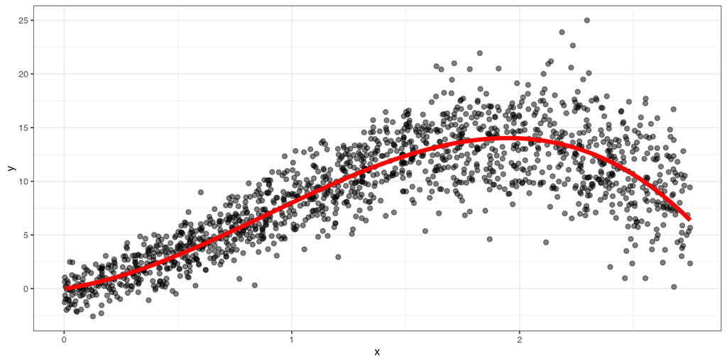

## Conditional expectations vs Conditional expectation function (CEF)

Conditional expectation ${\textrm E}[Y | X = x]$ is for a specific $x$.

Conditional expectation function (CEF) ${\textrm E}[Y | X]$ is for all $x$.

## CEF as best predictor

The CEF ${\textrm E}[Y | X]$ is the expectation of $Y$ at each $X$.

We already established that the expectation/mean is the best (in MSE sense) predictor.

So CEF is the best possible way to use $X$ to predict $Y$. (See Theorem 2.2.20.)

**Multivariate generalization**: ${\textrm E}[Y \mid X_1, X_2, X_3, \ldots, X_n]$ is the best way to use $X_1, \ldots X_n$ to predict $Y$.

## Law of iterated expectations

For random variables $X$ and $Y$,

$${\textrm E}[Y] = {\textrm E}[{\textrm E}[Y | X]]$$

This means there are two ways to get ${\textrm E}[Y]$:

- start with $f(y)$, take expectations: ${\textrm E}[Y] = \sum_y y f(y)$
- start with ${\textrm E}[Y \mid X]$ and $f_X(x)$, take expectations: ${\textrm E}[Y] = \sum_x {\textrm E}[Y \mid X=x] f_X(x)$

In words: An unconditional average (${\textrm E}[Y]$) can be represented as a weighted average of conditional expectations (${\textrm E}[Y \mid X]$) with weights taken from the distribution of the variable conditioned on, i.e. $X$.

Why would you want to do that?

## LIE: An intuitive example

A population is 80% female and 20% male.

The average age among females (${\textrm E}[Y | X = 1]$) is 25. The average age among males ${\textrm E}[Y | X = 0]$ is 20.

What is the average age in the population, ${\textrm E}[Y]$?

$${\textrm E}[{\textrm E}[Y | X]] = .8 \times 25 + .2 \times 20 = 24$$

See homework for another example.

## LIE: another example

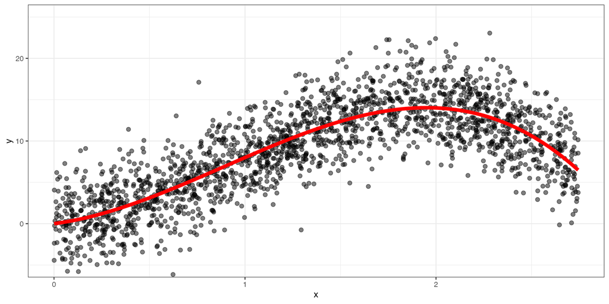

## LIE: another example (2)

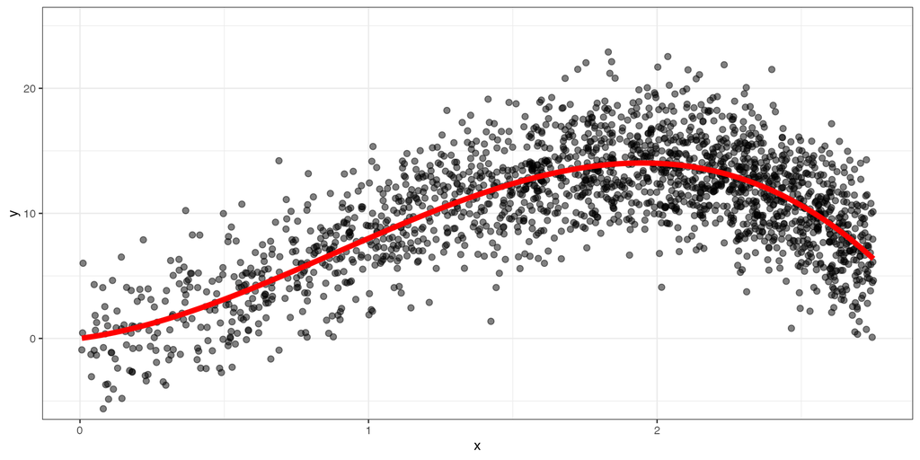

## How LIE is used in causal inference (preview)

Suppose we want to measure the average effect of participating in a program (e.g. job training, voter education, military mobilization).

Call $Y$ the (unobservable) effect of the treatment. We want the **average treatment effect** (ATE), ${\textrm E}[Y]$.

Suppose that comparing participants and non-participants gives us a good estimate of the average treatment effect only within subgroups defined by age ($X$).

So we have ${\textrm E}[Y \mid X]$.

Now we just combine these estimates (by LIE): ${\textrm E}[Y] = {\textrm E}[{\textrm E}[Y \mid X]] = \sum_{x} {\textrm E}[Y \mid X = x] f(x)$

## Law of total variance

$${\textrm V}[Y] = {\textrm E}[{\textrm V}[Y|X]] + {\textrm V}[{\textrm E}[Y|X]]$$

In words, the variance of $Y$ can be **decomposed** into the expected conditional variance (${\textrm E}[{\textrm V}[Y|X]]$) and the variance of the conditional expectation (${\textrm V}[{\textrm E}[Y|X]]$).

Sometimes called “Ev(v)e’s law” because

$${\textrm V}[Y] = \color{red}{{\textrm E}}[\color{red}{{\textrm V}}[Y|X]] + \color{red}{{\textrm V}}[\color{red}{{\textrm E}}[Y|X]]$$

## Law of total variance (2)

## Best linear predictor (BLP)

Suppose we want to predict $Y$ using $X$, and we focus on a linear predictor, i.e. a function of the form $\alpha + \beta X$.

The best (minimum MSE) predictor satisfies

$$(\alpha, \beta) = \underset{(a,b) \in \mathbb{R}^2}{\arg\min} \, {\textrm E}\,[\left(Y - (a + bX)\right)^2]$$

The solution (see Theorem 2.2.21) is

- $\beta = \frac{\textrm{Cov}[X, Y]}{\textrm{V}[X]}$
- $\alpha = {\textrm E}[Y] - \beta {\textrm E}[X]$

So we could obtain the BLP from a joint PMF. (See homework.)

## BLP predicts CEF

Above, we were looking for best linear predictor (BLP) of $Y$ as function of $X$:

$$(\alpha, \beta) = \underset{(a,b) \in \mathbb{R}^2}{\arg\min} \, {\textrm E}[\left(Y - (a + bX)\right)^2]$$

Same answer if you look for the best linear predictor of the CEF $E[Y | X]$:

$$(\alpha, \beta) = \underset{(a,b) \in \mathbb{R}^2}{\arg\min} \, {\textrm E}[\left({\textrm E}[Y|X] - (a + bX)\right)^2]$$

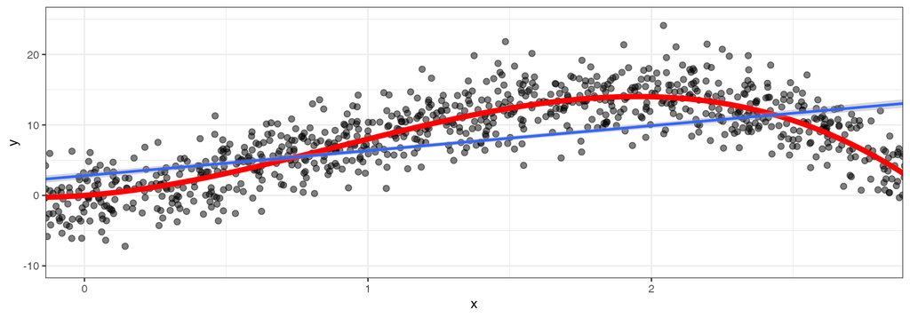